# Assignment-1

va306

2/05/2023

```r
## Import csv file from dataset
library(readr)
Bumpus_sparrows <- read_csv("C:/Users/vidhi/Downloads/Bumpus_sparrows.csv")
Bumpus_sparrows
```

```
## # A tibble: 49 × 6
##    Survivorship Total_length Alar_extent L_beak_head L_humerous L_keel_sternum
##    <chr>               <dbl>       <dbl>       <dbl>      <dbl>          <dbl>
##  1 S                     156         245        31.6       18.5           20.5
##  2 S                     154         240        30.4       17.9           19.6
##  3 S                     153         240        31         18.4           20.6
##  4 S                     153         236        30.9       17.7           20.2
##  5 S                     155         243        31.5       18.6           20.3
##  6 S                     163         247        32         19             20.9
##  7 S                     157         238        30.9       18.4           20.2
##  8 S                     155         239        32.8       18.6           21.2
##  9 S                     164         248        32.7       19.1           21.1
## 10 S                     158         238        31         18.8           22
## # … with 39 more rows
```

```r
sparr <- Bumpus_sparrows
sparr
```

```
## # A tibble: 49 × 6
##    Survivorship Total_length Alar_extent L_beak_head L_humerous L_keel_sternum
##    <chr>               <dbl>       <dbl>       <dbl>      <dbl>          <dbl>
##  1 S                     156         245        31.6       18.5           20.5
##  2 S                     154         240        30.4       17.9           19.6
##  3 S                     153         240        31         18.4           20.6
##  4 S                     153         236        30.9       17.7           20.2
##  5 S                     155         243        31.5       18.6           20.3
##  6 S                     163         247        32         19             20.9
##  7 S                     157         238        30.9       18.4           20.2
##  8 S                     155         239        32.8       18.6           21.2
##  9 S                     164         248        32.7       19.1           21.1
## 10 S                     158         238        31         18.8           22
## # … with 39 more rows
```

## Survived Sparrow Matrix

```r
survived=subset(sparr,Survivorship=='S')
survived
```

```
## # A tibble: 21 × 6
##    Survivorship Total_length Alar_extent L_beak_head L_humerous L_keel_sternum
##    <chr>               <dbl>       <dbl>       <dbl>      <dbl>          <dbl>
##  1 S                     156         245        31.6       18.5           20.5
##  2 S                     154         240        30.4       17.9           19.6
##  3 S                     153         240        31         18.4           20.6
##  4 S                     153         236        30.9       17.7           20.2
##  5 S                     155         243        31.5       18.6           20.3
##  6 S                     163         247        32         19             20.9
##  7 S                     157         238        30.9       18.4           20.2
##  8 S                     155         239        32.8       18.6           21.2
##  9 S                     164         248        32.7       19.1           21.1
## 10 S                     158         238        31         18.8           22
## # … with 11 more rows
```

```r
# Removing the non-numeric values

survived_num = survived[,-1]
survived_num
```

```
## # A tibble: 21 × 5
##    Total_length Alar_extent L_beak_head L_humerous L_keel_sternum
##           <dbl>       <dbl>       <dbl>      <dbl>          <dbl>
##  1          156         245        31.6       18.5           20.5
##  2          154         240        30.4       17.9           19.6
##  3          153         240        31         18.4           20.6
##  4          153         236        30.9       17.7           20.2
##  5          155         243        31.5       18.6           20.3
##  6          163         247        32         19             20.9
##  7          157         238        30.9       18.4           20.2
##  8          155         239        32.8       18.6           21.2
##  9          164         248        32.7       19.1           21.1
## 10          158         238        31         18.8           22
## # … with 11 more rows
```

## Colmeans Survivorship

```r
colMeans(survived_num)
```

```
##   Total_length    Alar_extent    L_beak_head     L_humerous L_keel_sternum
##      157.38095      241.00000       31.43333       18.50000       20.80952
```

## Covariance Survivorship

```r
## Covariance Survivorship
cov(survived_num)
```

```
##                Total_length Alar_extent L_beak_head L_humerous L_keel_sternum
## Total_length      11.047619        9.10   1.5566667     0.8700      1.2861905
## Alar_extent        9.100000       17.50   1.9100000     1.3100      0.8800000
## L_beak_head        1.556667        1.91   0.5313333     0.1890      0.2396667
## L_humerous         0.870000        1.31   0.1890000     0.1760      0.1325000
## L_keel_sternum     1.286190        0.88   0.2396667     0.1325      0.5749048
```

```r
cods=cov(survived_num)
cods
```

```
##                Total_length Alar_extent L_beak_head L_humerous L_keel_sternum
## Total_length      11.047619        9.10   1.5566667     0.8700      1.2861905
## Alar_extent        9.100000       17.50   1.9100000     1.3100      0.8800000
## L_beak_head        1.556667        1.91   0.5313333     0.1890      0.2396667
## L_humerous         0.870000        1.31   0.1890000     0.1760      0.1325000
## L_keel_sternum     1.286190        0.88   0.2396667     0.1325      0.5749048
```

## Inference for Covariance Survivorship

- The covariance between Alar_extent and Total_Length is the maximum in the matrix column i.e. 9.1. It is a positive covariance. As the total_length increases Alar_extent also increase.
- The covariance between the L_hemerous and L_keel_sternum is the least. The covariance is very close to 0 and it can be inferred that there might be no relationship between L_hemerous and L_keel_sternum.

## Corelation Survivorship

```r
## Correlation Survivorship
cor(survived_num)
```

```
##                Total_length Alar_extent L_beak_head L_humerous L_keel_sternum
## Total_length      1.0000000   0.6544674   0.6425068  0.6239195      0.5103557
## Alar_extent       0.6544674   1.0000000   0.6263698  0.7464418      0.2774378
## L_beak_head       0.6425068   0.6263698   1.0000000  0.6180476      0.4336368
## L_humerous        0.6239195   0.7464418   0.6180476  1.0000000      0.4165447
## L_keel_sternum    0.5103557   0.2774378   0.4336368  0.4165447      1.0000000
```

## Inference for Correlation Survivorship

- The correlation is usually between -1 to 1. As seen from the matrix, we mostly have a positive correlation.
- The maximum correlation is between the l_humerous and Alar_extent of approx 0.74.The survival chance are strongly dependednt on these 2 variables.

## Non-Survived Sparrow Matrix

```r
N_survived=subset(sparr,Survivorship=='NS')
N_survived
```

```
## # A tibble: 28 × 6
##    Survivorship Total_length Alar_extent L_beak_head L_humerous L_keel_sternum
##    <chr>               <dbl>       <dbl>       <dbl>      <dbl>          <dbl>
##  1 NS                    155         240        31.4       18             20.7
##  2 NS                    156         240        31.5       18.2           20.6
##  3 NS                    160         242        32.6       18.8           21.7
##  4 NS                    152         232        30.3       17.2           19.8
##  5 NS                    160         250        31.7       18.8           22.5
##  6 NS                    155         237        31         18.5           20
##  7 NS                    157         245        32.2       19.5           21.4
##  8 NS                    165         245        33.1       19.8           22.7
##  9 NS                    153         231        30.1       17.3           19.8
## 10 NS                    162         239        30.3       18             23.1
## # … with 18 more rows
```

```r
### Removing the non-numeric values
N_survived[,-1]
```

```
## # A tibble: 28 × 5
##    Total_length Alar_extent L_beak_head L_humerous L_keel_sternum
##           <dbl>       <dbl>       <dbl>      <dbl>          <dbl>
##  1          155         240        31.4       18             20.7
##  2          156         240        31.5       18.2           20.6
##  3          160         242        32.6       18.8           21.7
##  4          152         232        30.3       17.2           19.8
##  5          160         250        31.7       18.8           22.5
##  6          155         237        31         18.5           20
##  7          157         245        32.2       19.5           21.4
##  8          165         245        33.1       19.8           22.7
##  9          153         231        30.1       17.3           19.8
## 10          162         239        30.3       18             23.1
## # … with 18 more rows
```

```r
N_survived_num = N_survived[,-1]
```

```r
colMeans(N_survived_num)
```

```
##   Total_length    Alar_extent    L_beak_head     L_humerous L_keel_sternum
##      158.42857      241.57143       31.47857       18.44643       20.83929
```

## Covariance Non-Survivors

```r
cov_data=cov(N_survived_num)
cov_data
```

```
##                Total_length Alar_extent L_beak_head L_humerous L_keel_sternum
## Total_length      15.068783   17.190476   2.2428571  1.7460317      2.9306878
## Alar_extent       17.190476   32.550265   3.3978836  2.9502646      4.0656085
## L_beak_head        2.242857    3.397884   0.7284127  0.4695503      0.5590212
## L_humerous         1.746032    2.950265   0.4695503  0.4344312      0.5058862
## L_keel_sternum     2.930688    4.065608   0.5590212  0.5058862      1.3209921
```

## Corelation Non-Survivors

```r
cor(N_survived_num)
```

```
##                Total_length Alar_extent L_beak_head L_humerous L_keel_sternum
## Total_length      1.0000000   0.7761963   0.6769768  0.6824212      0.6568714
## Alar_extent       0.7761963   1.0000000   0.6978185  0.7845546      0.6200093
## L_beak_head       0.6769768   0.6978185   1.0000000  0.8347046      0.5698878
## L_humerous        0.6824212   0.7845546   0.8347046  1.0000000      0.6677936
## L_keel_sternum    0.6568714   0.6200093   0.5698878  0.6677936      1.0000000
```

- As all the values are positive, we can see there has no negative correlation.
- The maximum is the correlation between the variables l_humerous and l_beak_head. The value shows it’s a strong positive correlation.It’s contrary to the the variables relation in covariance matrix.

```r
# Extra material for inference
```

# CONCLUSION with Comparing Total length

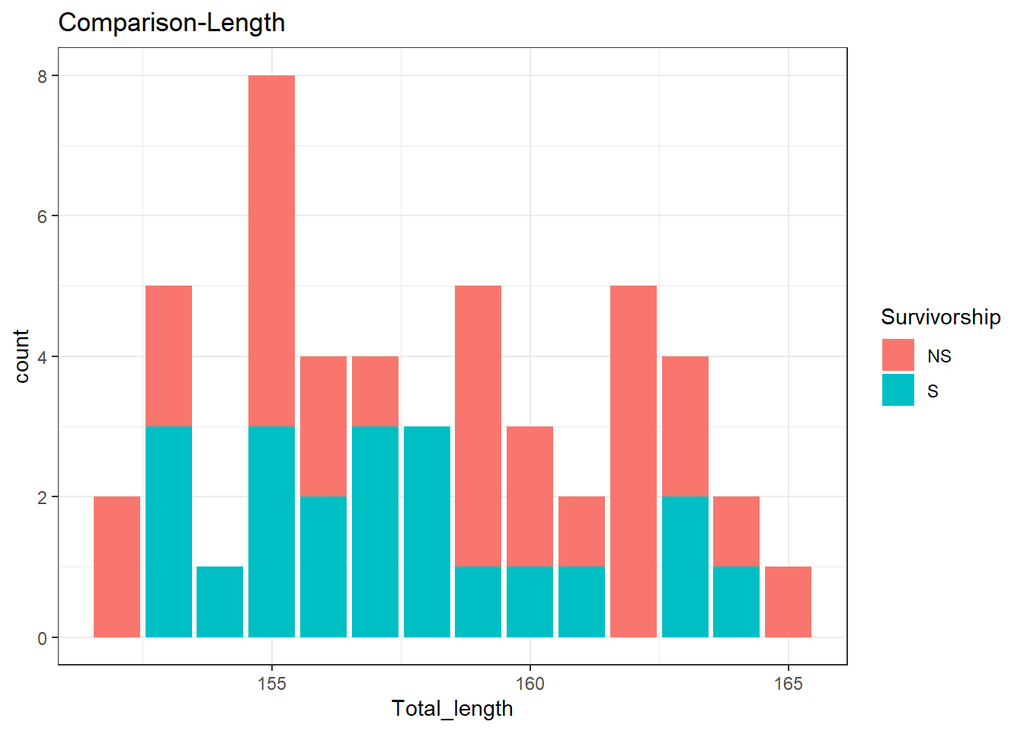

```r
library(ggplot2)
ggplot(sparr,aes(x=Total_length, fill=Survivorship))+geom_bar()+theme_bw()+
labs(title='Comparison-Length')
```

#Inference from the Total_length graph:

- As the Total_length increases the chances of Sparrows Surviving is less as compared to birds with shorter length.

# CONCLUSION with Comparing Alar_extent

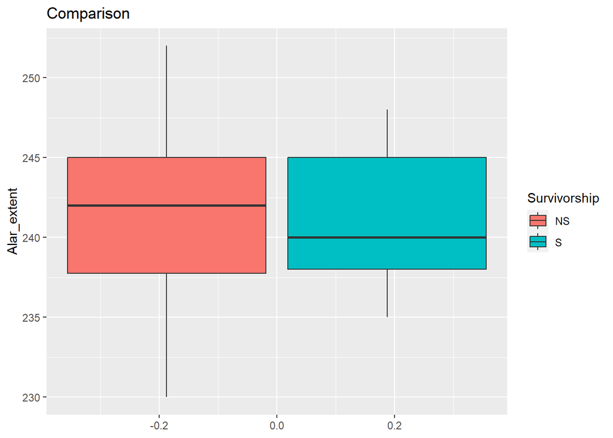

```r
ggplot(sparr,aes(y=Alar_extent, fill=Survivorship))+geom_boxplot()+
labs(title='Comparison')
```